# Session 3

Lauren Yee

April 7nd, 2020

# Visualization and Reproducible Reports in R

## Session 3

### April 7nd, 2020

# Visualization and Reproducible Reports in R

## Presented By:

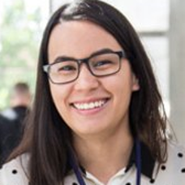

**Lauren Yee** is multifaceted researcher and data scientist. She currently works in the consulting industry and designs projects around data visualization, dashboards and ecological and spatial analysis.

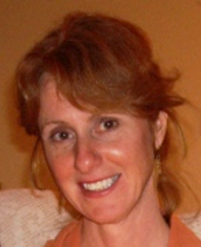

**Ann Greenwood** is the Education and Training Lead for Population Data BC. She manages a variety of education and training services for researchers and population health professionals . Services include an online certificate course in Population Health Data Analysis, live webinar-based courses, free online self -paced workshops, colloquium presentations/webinars and in-person workshops.

# Session 3

Components of the Layered Grammar (cont’d)

Creating your own themes

Many plots in ggplot2

Faceting

Patchwork

Parameters in R Markdown

Visualizing spatial data in ggplot2

Intro to sf

geoms_sf()

# Components of the Layered Grammar

- data and aesthetic mappings
- geometric objects
- scales
- statistics and transformations
- **a coordinate system**
- **facet specification**
- **themes**

# Coordinate system

- combines aesthetics to produce a 2d position on the plot `x` and `y` `coord_cartesian()`: the default system

`coord_flip()`: flips the cartesian coordinate system

`coord_fixed()`: fixed aspect ratio

`coord_map()/coord_quickmap()/coord_sf()`: Map projections

`coord_polar()`: Polar coordinates

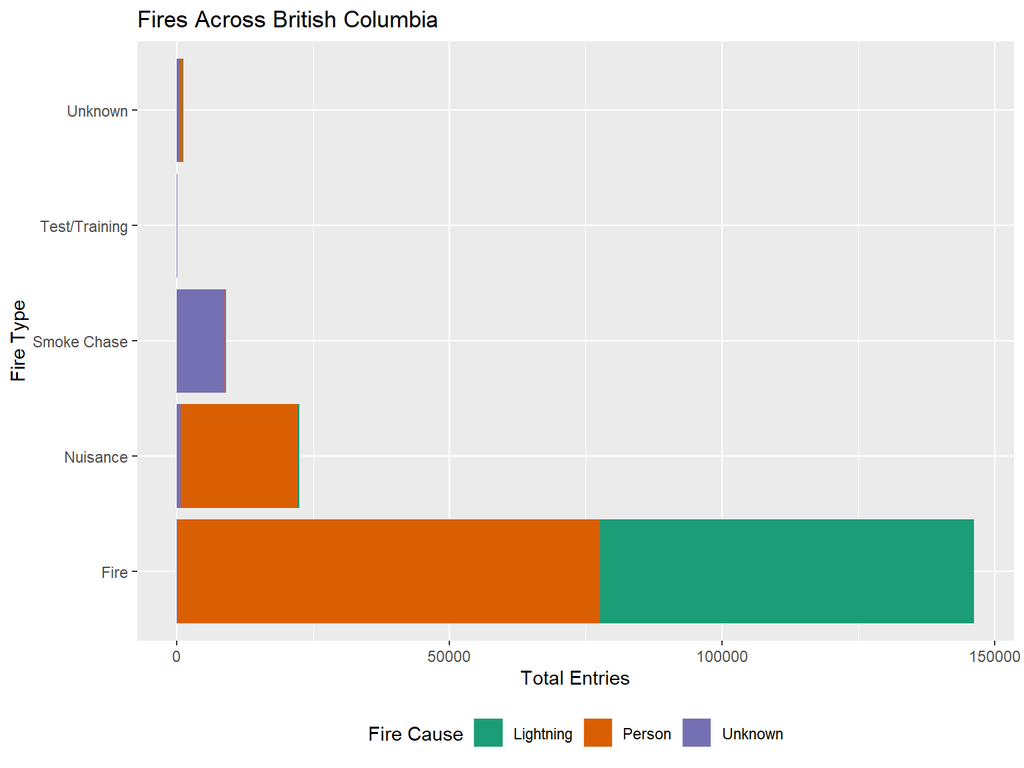

```r
ggplot(data=wildfire_table, aes(x=FIRE_TYPE))+
  scale_fill_brewer(type="qual",palette = "Dark2")+
  geom_bar(aes(fill=FIRE_CAUSE))+
  labs(x="Fire Type", y="Total Entries",fill="Fire Cause",title = "Fires Across British Columbia")+
  coord_flip()+
  theme(legend.position = "bottom")
```

# Facet

Facets allow you to plot many of the same plots by a specific variable.

There are two types of facets in ggplot2. `facet_grid` and `facet_wrap`

**Facet grid**: Forms a matrix of panels defined by faceting variables

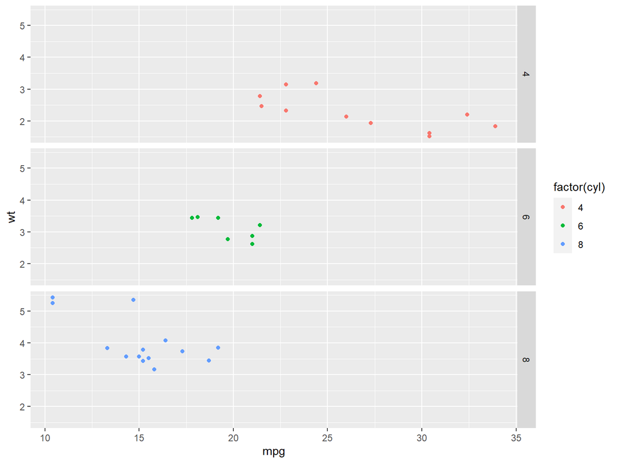

```r
mt <- ggplot(mtcars, aes(mpg, wt, colour = factor(cyl))) +
  geom_point()

mt + facet_grid(vars(cyl))
```

**Facet wrap** where `vars` is the column to facet on. Best for one variable many levels. Specify the number of column and rows.

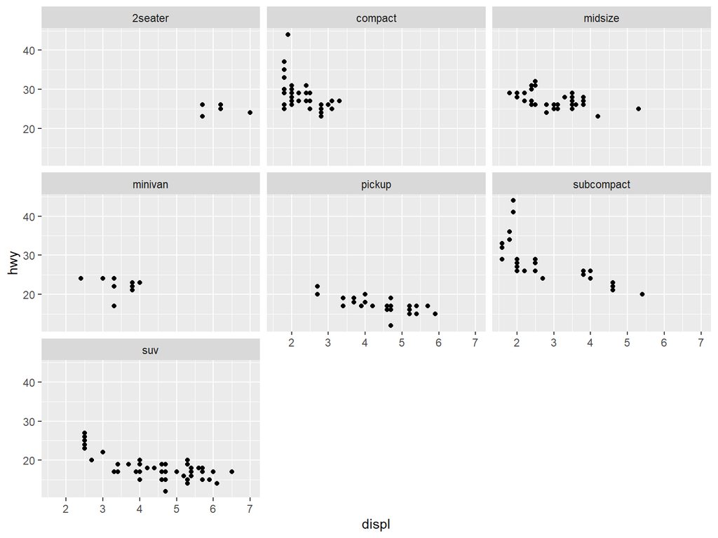

```r
p <- ggplot(mpg, aes(displ, hwy)) + geom_point()


p + facet_wrap(vars(class))
```

# Themes

Theme elements are separated with commas, not `+`

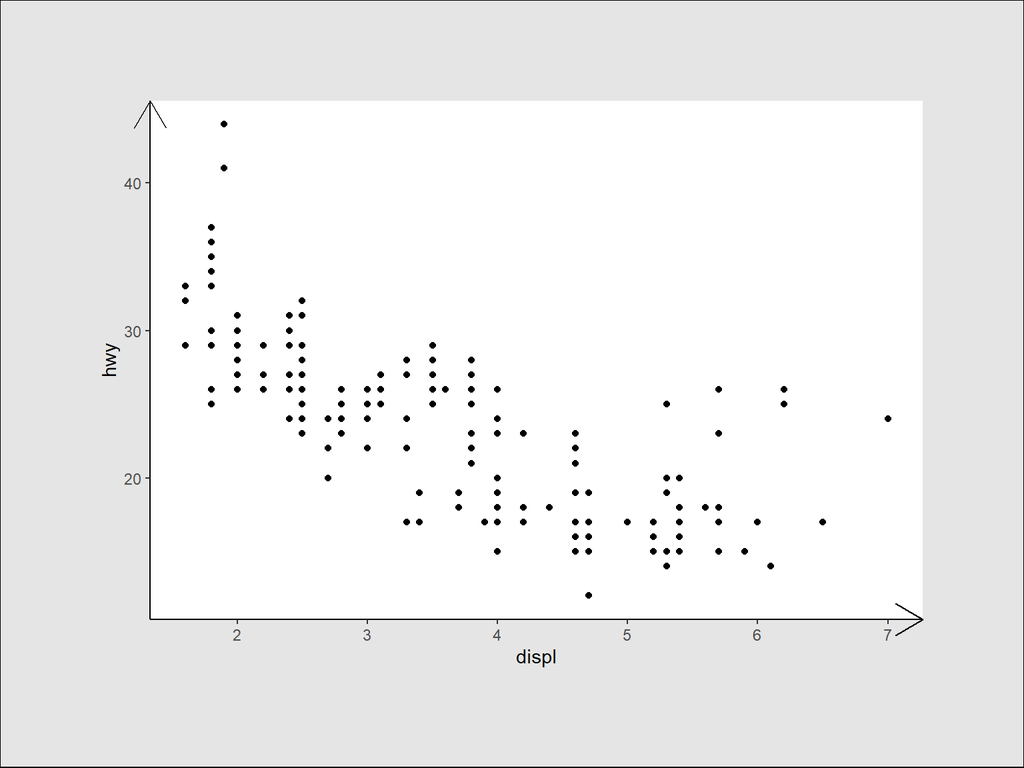

```r
plot <- ggplot(mpg, aes(displ, hwy)) + geom_point()

plot +
  theme(
    axis.line = element_line(arrow = arrow()),
    panel.background = element_rect(fill = "white"),
    plot.margin = margin(2, 2, 2, 2, "cm"),
    plot.background = element_rect(
      fill = "grey90",
      colour = "black"
    )

  )
```

# BBC Themes

https://github.com/bbc/bbplot/blob/master/R/bbc_style.R

# Parameters in Markdown

Parameters are useful when you want to render the same report with distinct values for various key inputs, for example:

- Running a report specific to a department or geographic region.
- Running a report that covers a specific period in time
- Running multiple versions of a report for distinct sets of core assumptions.

Setting Parameters in the YAML header allows you to assign those parameters within markdown. For example, in the code below we have included `file_path` as a parameter in the YAML header:

```r
---
title: "Markdown_Report"
author: "Lauren"
date: "April 4, 2020"

output: word_document
params:
  file_path: "./Output/wildfire_2016.csv"

---
```

We can also assign these values through this line of code:

`render("Markdown_Report.Rmd", params = list(file_path = "./Output/wildfire_2016.csv"))`

To use parameters in your code you can reference them as `params$file_path` with the `$` separating your defined parameter

# Parameters

Since we output two different years, let’s also set up a year parameter

```r
---
title: "Markdown_Report"
author: "Lauren"
date: "April 4, 2020"
output:
  html_document:
  params:
    file_path: "./Output/wildfire_2016.csv"
    year: 2016

---
```

# Parameters

Run the same report for the year 2017

`rmarkdown::render("Markdown_report.rmd",params=list(file_path="./Output/wildfire_2017.csv", year=2017))`

To name output files - create a function

```r
render_report = function(file_path, year) {
  rmarkdown::render(
    "Markdown_Report.Rmd", params = list(
      file_path= file_path,
      year = year
    ),
    output_file = paste0("Report-", year, ".docx")
  )
}
```

Additionally we can use `rmarkdown::render("Markdown_Report.Rmd", params = "ask")` for a graphical interface to pop up so the user can input the parameters.

# Within Markdown

```r
library(dplyr)
library(ggplot2)
library(lubridate)
library(knitr)
#library(tidyverse)

wildfire_table<-readr::read_csv(params$file_path, col_types=list("c","n","c","c","c","n","n","n","c","c","n","n","n","c","c","n"))
```

# Today’s Session

- Finish session 2
- Session3_Processing01.Rmd
- Markdown_Report.Rmd
- Session 3 Exercise

# Sources

http://vita.had.co.nz/papers/layered-grammar.pdf

https://ggplot2.tidyverse.org/

https://r4ds.had.co.nz/data-visualisation.html

https://bookdown.org/yihui/rmarkdown/parameterized-reports.html